# practical_exercise_3, Methods 3, 2021, autumn semester

[Sara Viuf ]

[5-10-2021]

## Exercise 1

```r
#Loading data and fixing data frame.
mydir = "experiment_2"
d = list.files(path=mydir, pattern="*.csv", full.names=TRUE)
df = ldply(d, read_csv)
#Fixing classes
df$trial.type <- as.factor(df$trial.type)
df$pas <- as.factor(df$pas)
df$trial <- as.factor(df$trial)
df$task <- as.factor(df$task)
df$subject <- as.factor(df$subject)
df$target.type <- as.factor(df$target.type)
df$obj.resp <- as.factor(df$obj.resp)
str(df)
```

```
## 'data.frame':    18131 obs. of  17 variables:
##  $ trial.type     : Factor w/ 2 levels "experiment","staircase": 2 2 2 2 2 2 2 2 2 2 ...
##  $ pas            : Factor w/ 4 levels "1","2","3","4": 4 4 4 4 4 4 4 4 4 4 ...
##  $ trial          : Factor w/ 432 levels "0","1","2","3",..: 1 2 3 4 5 6 7 8 9 10 ...
##  $ jitter.x       : num  -0.3425 0.0623 -0.4058 -0.3615 0.2891 ...
##  $ jitter.y       : num  0.4489 0.0291 0.4995 -0.2224 0.4132 ...
##  $ odd.digit      : num  9 9 7 7 7 7 7 7 9 9 ...
##  $ target.contrast: num  1 1 0.9 0.9 0.8 0.8 0.5 0.5 0.3 0.3 ...
##  $ target.frames  : num  3 3 3 3 3 3 3 3 3 3 ...
##  $ cue            : num  29 29 29 29 29 29 29 29 29 29 ...
##  $ task           : Factor w/ 3 levels "pairs","quadruplet",..: 1 1 1 1 1 1 1 1 1 1 ...
##  $ target.type    : Factor w/ 2 levels "even","odd": 2 1 1 2 1 1 2 2 1 2 ...
##  $ rt.subj        : num  1.754 1.39 0.686 0.653 0.582 ...
##  $ rt.obj         : num  1.158 2.456 0.951 0.62 0.95 ...
##  $ even.digit     : num  8 4 4 4 4 4 4 4 4 8 ...
##  $ seed           : num  9817 9817 9817 9817 9817 ...
##  $ obj.resp       : Factor w/ 2 levels "e","o": 2 1 1 2 1 1 2 2 1 2 ...
##  $ subject        : Factor w/ 29 levels "001","002","003",..: 1 1 1 1 1 1 1 1 1 1 ...
```

```r
#Adding column, 1 means the participant response was correct, 0 means it was incorrect.
df$correct = 0
df$correct = as.logical(ifelse(df$obj.resp == "e" & df$target.type =="even", 1,
                              ifelse(df$obj.resp == "o" & df$target.type =="odd", 1,
                                     ifelse(df$obj.resp == "e" & df$target.type =="odd", 0,
                                            ifelse(df$obj.resp == "o" & df$target.type =="even", 0, NA)))))
```

These are the variables in the data set: *trial.type* -> describes if the trial is staircase or experiment. *pas* -> describes score from 1 to 4 on the Perceptual Awareness Scale. *trial* -> for both trial types this indicates trial number. *target.contrast* -> numeric grey scale, range 0-1. Higher number means more intense coloring of the target digit. *cue* -> indicates what number was used when cueing *task* -> how many numbers could be shown; has the levels quadruplet: (all numbers); pairs: (2 even and 2 odd numbers); singles: (1 even and 1 odd number) *target_type* -> indicates whether the target shown was a number from the column ‘odd.digit’ or ‘even.digit’ *rt.subj* -> reaction time, seconds, of the pas responses. *rt.obj* -> reaction time, seconds, how long did it take the participant to respond to the target digit. *obj.resp* -> describes what key the the participant pressed, ‘o’ for odd or ‘e’ for even *subject* -> subject number. *correct* -> If the response was correct.

```r
#Subsetting dataframe to only include the 'staircase' trial type.
staircase_df <- df %>%
  filter(trial.type == "staircase")

#no-pool model, predicting correct based on target.contrast. No random effects. Since correct is logical, the model should be logistic.
m <- glm(correct~target.contrast, data=staircase_df, family = binomial(link="logit"))
summary(m)
```

```
##
## Call:
## glm(formula = correct ~ target.contrast, family = binomial(link = "logit"),
##     data = staircase_df)
##
## Deviance Residuals:
##     Min       1Q   Median       3Q      Max
## -2.7893   0.2359   0.7419   0.7748   0.8296
##
## Coefficients:
##                 Estimate Std. Error z value Pr(>|z|)
## (Intercept)      0.85958    0.04522   19.01   <2e-16 ***
## target.contrast  3.00974    0.36394    8.27   <2e-16 ***
## ---
## Signif. codes:  0 '***' 0.001 '**' 0.01 '*' 0.05 '.' 0.1 ' ' 1
##
## (Dispersion parameter for binomial family taken to be 1)
##
##     Null deviance: 6127.2  on 5602  degrees of freedom
## Residual deviance: 6004.5  on 5601  degrees of freedom
## AIC: 6008.5
##
## Number of Fisher Scoring iterations: 5
```

```r
r.squaredGLMM(m)
```

```
##                    R2m        R2c
## theoretical 0.08051353 0.08051353
## delta       0.04941751 0.04941751
```

```r
#Getting the fitted values.
staircase_df$fit = fitted.values(m)

#Plotting fitted values for the no pooling model.
p <- ggplot(staircase_df, aes(target.contrast, fit)) + geom_point()+ geom_smooth()+facet_wrap(~subject) + ggtitle("No pooling")

#Partial pooling logistic model, predicting response based on the grey shading of the digit. Modeling target.contrast as random slope, and subject as random intercept.
m1 <- glmer(correct~target.contrast + (1+target.contrast|subject), staircase_df, family = binomial(link = "logit"))
staircase_df$fit1 <- fitted.values(m1)
summary(m1)
```

```
## Generalized linear mixed model fit by maximum likelihood (Laplace
##   Approximation) [glmerMod]
##  Family: binomial  ( logit )
## Formula: correct ~ target.contrast + (1 + target.contrast | subject)
##    Data: staircase_df
##
##      AIC      BIC   logLik deviance df.resid
##   5988.5   6021.6  -2989.2   5978.5     5598
##
## Scaled residuals:
##     Min      1Q  Median      3Q     Max
## -5.7684  0.0068  0.5532  0.5915  0.9254
##
## Random effects:
##  Groups  Name            Variance Std.Dev. Corr
##  subject (Intercept)      0.2702  0.5198
##          target.contrast 42.3675  6.5090   -0.84
## Number of obs: 5603, groups:  subject, 29
##
## Fixed effects:
##                 Estimate Std. Error z value Pr(>|z|)
## (Intercept)       0.5635     0.1576   3.575 0.000350 ***
## target.contrast   8.6844     2.3527   3.691 0.000223 ***
## ---
## Signif. codes:  0 '***' 0.001 '**' 0.01 '*' 0.05 '.' 0.1 ' ' 1
##
## Correlation of Fixed Effects:
##             (Intr)
## trgt.cntrst -0.907
```

```r
r.squaredGLMM(m1)
```

```
##                   R2m       R2c
## theoretical 0.3301885 0.5470844
## delta       0.2935702 0.4864121
```

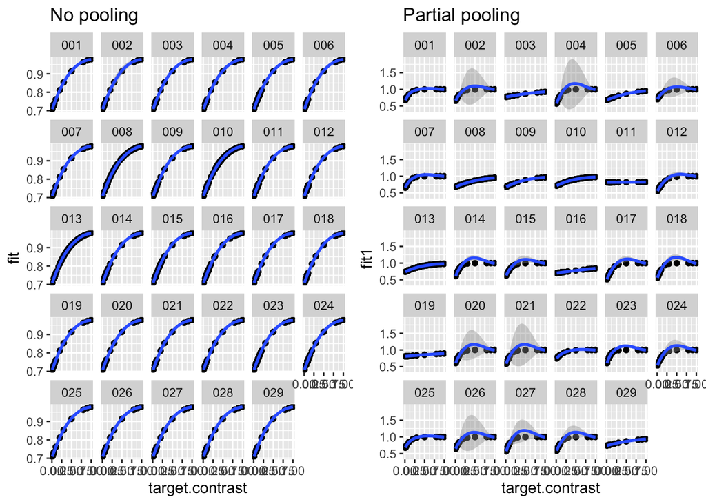

```r
#Plotting fitted values for the partial pooling model.
p1 <- ggplot(staircase_df, aes(target.contrast, fit1)) + geom_point()+ geom_smooth() + facet_wrap(~subject) + ggtitle("Partial pooling")

cowplot::plot_grid(p,p1)
```

```r
#The partial pooling allows for the individual response (correct/incorrect) to vary according to how each subject deals with specific grey shades on the screen. If you want to infer something about the population go with the no pooling, if  you wanna infer something about individuals go with the partial pooling model.
```

## Exercise 2

```r
#Filtering data to only include four subject and the experiment trial type.
sub <- filter(df, subject == "001" |subject == "002" |subject == "003" |subject == "004") %>%
  filter(trial.type == "experiment")

#Predicting rt.obj based on suject as random intercept.
m2 <- lmer(rt.obj ~ (1|subject), sub)
r.squaredGLMM(m2)
```

```
##      R2m         R2c
## [1,]   0 0.009005933
```

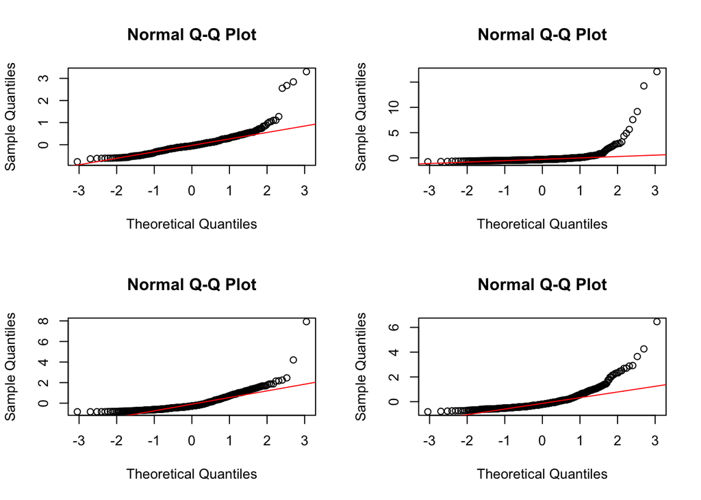

```r
#Making sure the following four plots are shown together
par(mfrow = c(2, 2))

#Adding column containing m2 residuals
sub$m2_res <- residuals(m2)

#QQplots for the four subjects individually
qqnorm(sub[sub$subject == "001", ]$m2_res)
qqline(sub[sub$subject == "001", ]$m2_res,
    col = "red")
qqnorm(sub[sub$subject == "002", ]$m2_res)
qqline(sub[sub$subject == "002", ]$m2_res,
    col = "red")
qqnorm(sub[sub$subject == "003", ]$m2_res)
qqline(sub[sub$subject == "003", ]$m2_res,
    col = "red")
qqnorm(sub[sub$subject == "004", ]$m2_res)
qqline(sub[sub$subject == "004", ]$m2_res,
    col = "red")
```

```r
#In one end of the plot there are large residuals, but in the other end they are minimal. There is a clear exponential trend in the residuals. This violates the assumption that the residuals should be normally distributed. I'll fix it with a log transformation.

#log transforming rt.obj to fix residuals.
m3 <- lmer(log(rt.obj) ~ (1|subject), sub)
r.squaredGLMM(m3)
```

```
##      R2m       R2c
## [1,]   0 0.0986374
```

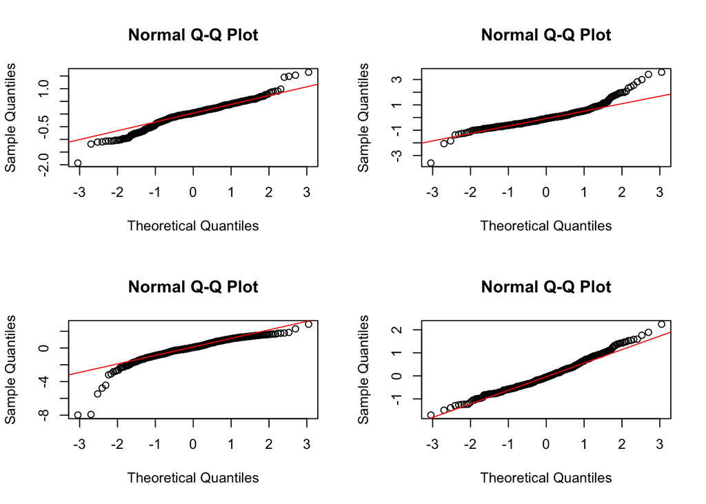

```r
#Adding column contains m3 residuals
sub$m3_res <- residuals(m3)

#Making sure the following four plots are shown together
par(mfrow = c(2, 2))

#QQplots for each of the four subjects.
qqnorm(sub[sub$subject == "001", ]$m3_res)
qqline(sub[sub$subject == "001", ]$m3_res,
    col = "red")
qqnorm(sub[sub$subject == "002", ]$m3_res)
qqline(sub[sub$subject == "002", ]$m3_res,
    col = "red")
qqnorm(sub[sub$subject == "003", ]$m3_res)
qqline(sub[sub$subject == "003", ]$m3_res,
    col = "red")
qqnorm(sub[sub$subject == "004", ]$m3_res)
qqline(sub[sub$subject == "004", ]$m3_res,
    col = "red")
```

```r
#The log transformation made the residuals at each end more equally deviant and less so. It helped.
```

```r
#I included subject as random intercept and grey shade as slope. rt.obj is still logtransformed
m4 <- lmer(log(rt.obj)~task + (1+target.contrast|subject),sub, REML=FALSE)
summary(m4)
```

```
## Linear mixed model fit by maximum likelihood  ['lmerMod']
## Formula: log(rt.obj) ~ task + (1 + target.contrast | subject)
##    Data: sub
##
##      AIC      BIC   logLik deviance df.resid
##   4137.0   4175.1  -2061.5   4123.0     1721
##
## Scaled residuals:
##     Min      1Q  Median      3Q     Max
## -9.9892 -0.5428  0.0051  0.4919  4.3660
##
## Random effects:
##  Groups   Name            Variance Std.Dev. Corr
##  subject  (Intercept)     0.09131  0.3022
##           target.contrast 4.08506  2.0212   -0.79
##  Residual                 0.63115  0.7944
## Number of obs: 1728, groups:  subject, 4
##
## Fixed effects:
##                Estimate Std. Error t value
## (Intercept)    -0.34427    0.11764  -2.926
## taskquadruplet -0.16222    0.04681  -3.465
## tasksingles    -0.16239    0.04681  -3.469
##
## Correlation of Fixed Effects:
##             (Intr) tskqdr
## taskqudrplt -0.199
## tasksingles -0.199  0.500
## optimizer (nloptwrap) convergence code: 0 (OK)
## unable to evaluate scaled gradient
## Model failed to converge: degenerate  Hessian with 1 negative eigenvalues
```

```r
#Minimal difference between tasks.
r.squaredGLMM(m4)
```

```
##              R2m        R2c
## [1,] 0.008503762 0.08368354
```